# Democracy, Sovereignty, and the Limits of Globalization

Stephen Weymouth

Dean’s Professor

2026-12-02

# In December 2001 Argentina limited bank withdrawals to defend its promise that one peso was worth one dollar. Within three weeks, riots had driven the president from office.

## Your IB Voice

A promise that failed

In the 1990s Argentina’s leaders did what global investors asked. In 2001 the investors left anyway. Using Rodrik, explain why.

**10 minutes** · Individual · Notes permitted

## Competing explanations

Why did Argentina’s commitment to global markets fail?

Shocks from abroad, such as Brazil’s devaluation, made the peso too expensive.

The fixed exchange rate was the wrong policy, and the government kept it too long.

Argentina’s leaders lacked the will to finish what they started.

Argentine voters would not accept the costs, and investors knew it.

Which of these could a more determined government have fixed?

# What did Argentina promise?

## The Convertibility Law ended hyperinflation

[figure not shown]

World Bank, [World Development Indicators](https://data.worldbank.org/indicator/NY.GDP.DEFL.KD.ZG?locations=AR): GDP deflator.

In March 1990 prices were rising at an annual rate above 20,000 percent.

The law, in force from April 1991, fixed the currency to the U.S. dollar.

Rodrik: the law “restored price stability practically overnight.”

## Argentina tied itself to the mast

[figure not shown]

John William Waterhouse, *Ulysses and the Sirens*, 1891 · National Gallery of Victoria, public domain

The law fixed the currency to the dollar, at one peso per dollar from 1992.

The central bank could issue more pesos only when dollars flowed in.

Cavallo wanted investors to believe that no later government could change the rules.

## Growth returned, then reversed after 1998

[figure not shown]

World Bank, [World Development Indicators](https://data.worldbank.org/indicator/NY.GDP.PCAP.KD?locations=AR): GDP per capita, constant dollars.

Foreign capital flowed in, and output per person rose 40 percent in eight years.

In January 1999 Brazil floated its currency, which fell about 40 percent against the dollar.

Argentina could not follow, so the rule that stopped inflation now made its exports too expensive.

## In 2001 the government cut pay to keep the peg

[figure not shown]

Rodrik, *The Globalization Paradox*, 2011; IMF Independent Evaluation Office, 2004.

When the cuts began, about one worker in six was already out of a job.

Rodrik: the government broke its contracts with public employees, pensioners, and depositors “so as not to skip one cent of its obligations to foreign creditors.”

## Investors were watching the voters

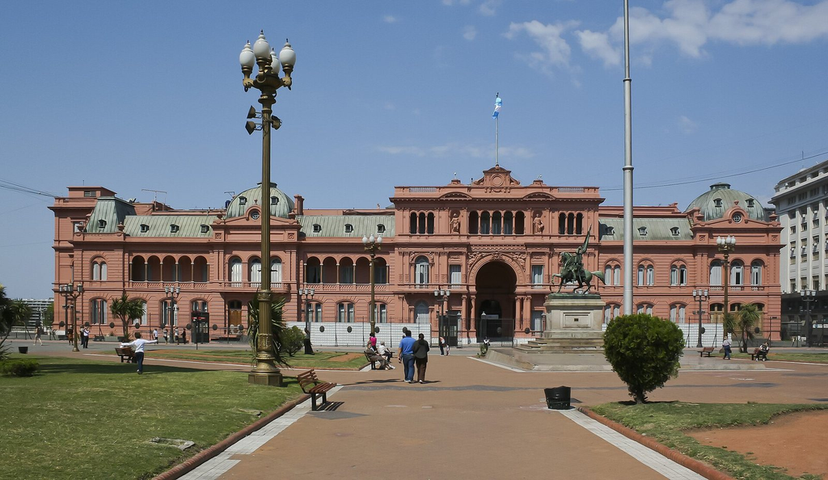

Diego Delso, [Casa Rosada, Buenos Aires](https://commons.wikimedia.org/wiki/File:Casa_Rosada,_Buenos_Aires,_Argentina.jpg), 2009 · Wikimedia Commons, CC BY-SA 3.0

When globalization collides with domestic politics, the smart money bets on politics.

Dani Rodrik, *The Globalization Paradox*, 2011

The government paid its foreign creditors until the month it fell, and investors left because they doubted that voters would accept more cuts.

## Fixed rules: the Golden Straitjacket

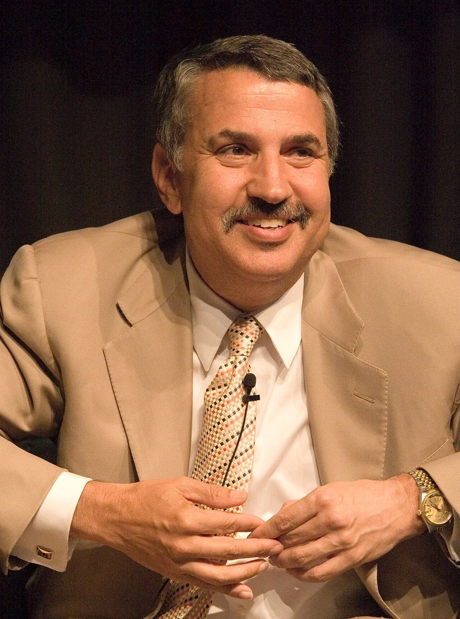

Charles Haynes, Thomas Friedman, 2005 · Wikimedia Commons, CC BY-SA 2.0

Deep integration asks a government to follow rules that investors trust.

The rules last only while voters accept what they cost.

Thomas Friedman called these rules the *Golden Straitjacket*. As Rodrik quotes him, “your economy grows, and your politics shrink.” Rodrik answers that democracy shrugs the straitjacket off.

# Where does deep integration limit what voters choose?

## Rodrik names five limits on national choice

[figure not shown]

Rodrik, *The Globalization Paradox*, 2011, Chapter 9.

In each case, making it cheaper to do business across borders leaves a country less room to choose its own rules.

# U.S. law bars your employer from replacing you with someone who will work 70 hours a week below the minimum wage. Trade lets the employer hire that worker abroad. Should the law treat the two differently?

## WTO judges overruled Europe’s beef ban

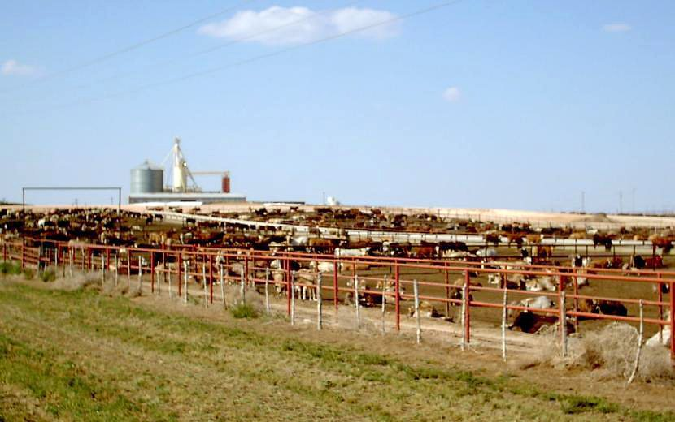

H2O, [Feedlot in the Texas Panhandle](https://commons.wikimedia.org/wiki/File:Feedlot-1.jpg) · Wikimedia Commons, CC BY-SA 3.0

The EU banned beef raised with growth hormones, whether European or imported.

In 1998 the WTO ruled that the ban did not rest on a scientific assessment of the risk.

Rodrik asks whether a democracy may “determine its own rules” and “make its own mistakes.”

# What are the choices?

## A country can have two of the three

[figure not shown]

Rodrik, *The Globalization Paradox*, 2011, Figure 9-1, redrawn.

**Hyperglobalization:** borders no longer interfere with trade or capital.

**Nation state:** each country makes its own rules.

**Democratic politics:** voters decide those rules.

Rodrik’s *political trilemma*: a country can have any two of these, and never all three.

## The vote

[figure not shown]

If you had to give one up, which would it be?

Rodrik’s own students give up the nation state, “hands-down.”

## Option 1: keep the rules and shrink democracy

[figure not shown]

Rodrik, *The Globalization Paradox*, 2011, Figure 9-1, redrawn.

Under the gold standard before 1914, governments put monetary rules ahead of jobs and wages at home.

Argentina wrote the same kind of rule into law in 1991.

Rodrik concludes that a country can keep globalization and the nation state “only if you keep democracy at bay.”

## Option 2: move democracy above the state

[figure not shown]

Rodrik, *The Globalization Paradox*, 2011, Figure 9-1, redrawn.

Global institutions would write the rules, and voters would hold those institutions to account.

The European Union is the regional example.

Rodrik doubts this can work worldwide, because countries differ too much to share rules that are more than “the lowest common denominator.”

## Option 3: keep democracy and limit globalization

[figure not shown]

Rodrik, *The Globalization Paradox*, 2011, Figure 9-1, redrawn.

After 1944 the Bretton Woods rules lowered trade barriers at the border and let countries restrict capital flows.

Countries could then tax, regulate, and promote industries in their own ways.

Rodrik chooses this option: a “thin” globalization that leaves each democracy room to differ.

## Bet on the promise or on the voters

[figure not shown]

**Will the promise hold?** Name who pays to keep it.

**10 minutes** · Groups of four · 6 to decide, 4 to report

[figure not shown]

**Britain, 2016:** your bank serves the EU from London, and voters just chose to leave.

[figure not shown]

**South Africa, 2007:** a treaty protects your quarries, and new rules require 26 percent Black ownership.

[figure not shown]

**European Union, 1998:** you export U.S. beef, and the WTO just ruled against the EU’s ban on it.

[figure not shown]

**Greece, 2015:** you own stores there, and voters just rejected the bailout terms.

# Britain left the EU’s single market at the end of 2020. Financial firms announced moves of about 7,000 jobs and £1.3 trillion in assets from London to the EU.

# South Africa let the investors keep their quarries on easier terms, and they dropped the case. It then began ending its investment treaties.

# The EU kept its ban. It opened a quota for hormone-free beef in 2009, and the United States ended its 100 percent tariffs on Roquefort and other European foods in 2011.

# Eight days after the vote, Greece’s government accepted stricter terms and stayed in the euro. Why did voters win in Argentina and lose in Greece?

## A promise is as strong as the voters behind it

[figure not shown]

Rodrik, *The Globalization Paradox*, 2011, Figure 9-1, with today’s cases added.

Before a firm relies on a government’s promise, it should ask who pays to keep the promise and whether they can vote it out.

## Closing discussion

[figure not shown]

Photographs from earlier sessions: D. L. Lu, S. Jurvetson, Clemensfranz, A. Genthe, B. Fuchs, and Geekerwan · Wikimedia Commons

Rodrik would give up some globalization to leave each democracy more room. Which firms from this course would lose the most?

# What did the semester add up to?

## We moved from the firm to the rules around it

[figure not shown]

Modules 1 to 4 asked what a firm owns and where it locates. Modules 5 to 9 asked who holds leverage, who pays, and who writes the rules.

Both halves answer the course’s central question about what makes a cross-border arrangement sustainable or vulnerable.

## Course takeaways

What can you now explain about any cross-border business?

**How it is organized:** a firm owns what is costly to contract for and puts each activity where its key input is cheapest.

**The political bargain:** leverage belongs to whoever holds what the other side cannot get elsewhere, and it shifts once an investment is sunk.

**The consequences:** the gains are spread widely, the losses fall on particular workers and places, and those places answer through politics.

**The response to change:** the links that make a firm efficient also carry shocks and coercion to it, so firms and governments pay to reduce their dependence.

## Dependence and consent decide what lasts

[figure not shown]

David Falconer, Oregon, 1973 · U.S. National Archives, public domain

An arrangement is vulnerable where one side depends on what another controls.

[figure not shown]

Barcex, Buenos Aires, 2002 · Wikimedia Commons, CC BY-SA 3.0

It is sustainable while the people who bear its costs accept it.

These are the course’s two answers to its central question, and Monday’s presentations apply both to your industries.

## The central question

How is cross-border business organized, and what makes the arrangements sustainable or vulnerable?